# JHEEM

2025-01-06

# PART 1: Code Setup and Implementation

```r
setwd("~/Documents/jheem_analyses")
getwd()
```

```
## [1] "/Users/yutaoyan/Documents/jheem_analyses"
```

```r
# Source the installation script
source("first_time_setup/install_packages.R")
```

```
## Skipping install of 'distributions' from a github remote, the SHA1 (808b78e8) has not changed since last install.
##   Use `force = TRUE` to force installation
```

```
## Skipping install of 'bayesian.simulations' from a github remote, the SHA1 (1da1851e) has not changed since last install.
##   Use `force = TRUE` to force installation
```

```
## Skipping install of 'locations' from a github remote, the SHA1 (914af72e) has not changed since last install.
##   Use `force = TRUE` to force installation
```

```r
library(distributions)
library(bayesian.simulations)
library(locations)
```

```r
list.files('../jheem_analyses/applications/ehe')
```

```
##  [1] "_archive"
##  [2] "awareness_covariance_calculations.R"
##  [3] "birth_death_rates_temp.R"
##  [4] "calculating_error_terms_for_ehe_likelihoods.R"
##  [5] "calibration_runs"
##  [6] "ehe_base_parameters.R"
##  [7] "ehe_bias_estimates_cache.R"
##  [8] "ehe_full_lik_temp.R"
##  [9] "ehe_high_risk_testing_ratios_from_brfss.R"
## [10] "ehe_likelihoods.R"
## [11] "ehe_ontology_mappings_original.R"
## [12] "ehe_ontology_mappings.R"
## [13] "ehe_parameter_mapping.R"
## [14] "ehe_parameters_helpers.R"
## [15] "ehe_parameters.R"
## [16] "ehe_prep_indications_from_atlas.R"
## [17] "ehe_prep_indications_from_nhanes_v2.R"
## [18] "ehe_prep_indications_from_nhanes.R"
## [19] "ehe_specification_helpers.R"
## [20] "ehe_specification.R"
## [21] "ehe_sti_included_multiplier.R"
## [22] "ehe_testing_prior_from_brfss.R"
## [23] "EHE_that_maps_exactly_to_original_version"
## [24] "general_solution_for_extracting_fit_intercept_and_slope.R"
## [25] "number_of_tests_sd.R"
## [26] "params.incomplete.mcmc_2024_02_20.Rdata"
## [27] "prior_specifications"
## [28] "steering_committee_figs.R"
```

```r
file.exists('../jheem_analyses/applications/EHE/ehe_specification.R')
```

```
## [1] TRUE
```

```r
file.exists("../jheem2/R/tests/source_jheem2_package.R")
```

```
## [1] TRUE
```

```r
source('../jheem_analyses/applications/EHE/ehe_specification.R')
```

```
## Loading Surveillance Manager (may take a minute or two)...Done!
## Loading Census Manager (may take a minute or two)...Done!
```

```r
exists("create.jheem.engine")
```

```
## [1] TRUE
```

```r
engine = create.jheem.engine(version = 'ehe', location = 'c.12580', end.year = 2025, max.run.time.seconds = 10)
```

```r
params = suppressWarnings(get.medians(EHE.PARAMETERS.PRIOR))
params['global.trate'] = 0.01
```

```r
sim = engine$run(parameters = params)
```

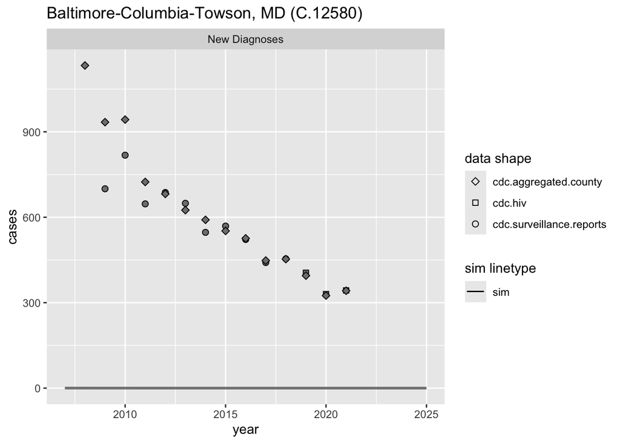

```r
simplot(sim, outcomes = "new", dimension.values = list(year = 2007:2025))
```

2. Diagnosed prevalence

```
## Warning: No shared levels found between `names(values)` of the manual scale and the
## data's fill values.
## No shared levels found between `names(values)` of the manual scale and the
## data's fill values.
```

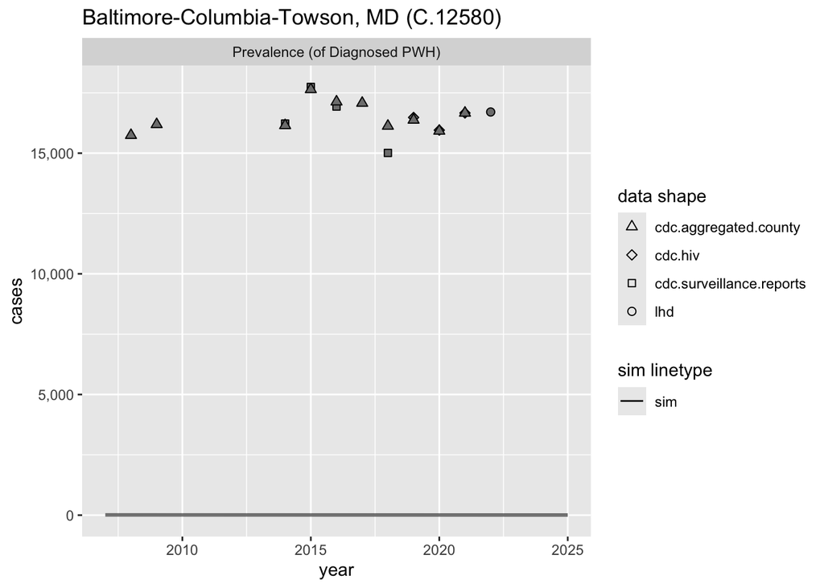

```r
simplot(sim, outcomes = "diagnosed.prevalence", dimension.values = list(year = 2007:2025))
```

```r
# Check the structure of the sim object
#str(sim)
#dimnames(sim$new)[[3]]  # Assuming the year is the 3rd dimension
#head(dimnames(sim$new)[[3]])  # View the first few values
#cleaned_years <- gsub("\\D", "", dimnames(sim$new)[[3]])  # Remove non-digit characters
#as.numeric(cleaned_years)
#valid_years <- as.numeric(cleaned_years)  # Ensure numeric format
#year_indices <- which(valid_years %in% 2007:2025)
#subset_data <- sim$new[, , year_indices, , , , , drop = FALSE]

#print(dimnames(subset_data))
```

# PART 2: Code Implementation and Analysis

```r
# Load necessary libraries
library(ggplot2)

# Set the seed for reproducibility
set.seed(1234)
# Ensures consistent results in random number generation (e.g., for rnorm used to simulate target data).
# Extract calibration targets
new.diagnosis.target=SURVEILLANCE.MANAGER$pull(outcome="diagnoses", location="C.12580",source="cdc.aggregated.county")
diagnosed.prevalence.target= SURVEILLANCE.MANAGER$pull(outcome="diagnosed.prevalence", location="C.12580",source="cdc.aggregated.county")
```

```r
# Define the model that calculates the prediction based on global.trate

model <- function(global.trate, time) {
  new.diagnosis.pred = global.trate * time
  diagnosed.prevalence.pred = global.trate * time^2

  return(list(new.diagnosis.pred = new.diagnosis.pred, diagnosed.prevalence.pred = diagnosed.prevalence.pred))
}
```

```r
# Loss function to minimize the error between predicted and target data
loss_function <- function(global.trate, time, new.diagnosis.target, diagnosed.prevalence.target) {
  # Generate predictions from the model
  predictions = model(global.trate, time)

  # Compute the squared error for both new diagnosis and diagnosed prevalence
  new.diagnosis.error = sum((predictions$new.diagnosis.pred - new.diagnosis.target)^2)
  diagnosed.prevalence.error = sum((predictions$diagnosed.prevalence.pred - diagnosed.prevalence.target)^2)

  # Return the total loss (sum of errors)
  total_loss = new.diagnosis.error + diagnosed.prevalence.error
  return(total_loss)
}
```

The loss function computes the squared error between the predicted values and the target data for both new.diagnosis.target and diagnosed.prevalence.target. The loss function uses the least squares method to optimize the fit between the model’s predictions and observed data for two outcomes: new diagnoses and diagnosed prevalence. By minimizing the total squared errors for these outcomes, the model adjusts the global transmission rate (global.trate) to best match the observed trends. This approach ensures that the predictions are as close as possible to the target values, providing a statistically sound and computationally efficient way to achieve the best fit.

```r
# Define time points and target values
time <- seq(1, 100, by = 1)
new.diagnosis.target <- rnorm(100, mean = 50, sd = 10)
diagnosed.prevalence.target <- rnorm(100, mean = 0.1, sd = 0.05)

# Use optim to find the best global.trate
result <- optim(par = 0.1,  # Initial guess for global.trate
                fn = loss_function,  # Loss function
                time = time,
                new.diagnosis.target = new.diagnosis.target,
                diagnosed.prevalence.target = diagnosed.prevalence.target,
                method = "BFGS")  # Optimization method

# Output the optimal value of global.trate
# Optimization: The optim() function minimizes the loss function by adjusting the value of global.trate.
best_trate <- result$par
cat("Best global.trate:", best_trate, "\n")
```

```
## Best global.trate: 0.0001397687
```

The result demonstrates the best value of global.trate that minimizes the error and provides the best fit to the target data.

```r
# Simulated data
time <- seq(2007, 2025, by = 1)  # Time from 2007 to 2025

# Simulate "new HIV diagnoses" and "prevalence of diagnosed HIV"
new_hiv_diagnoses <- rnorm(19, mean = 1500, sd = 300)  # Simulated data for new diagnoses
prevalence_diagnosed_hiv <- rnorm(19, mean = 0.1, sd = 0.02)  # Simulated data for prevalence

# Create a data frame with time and the two variables
sim_data <- data.frame(
  time = time,
  new_hiv_diagnoses = new_hiv_diagnoses,
  prevalence_diagnosed_hiv = prevalence_diagnosed_hiv
)
```

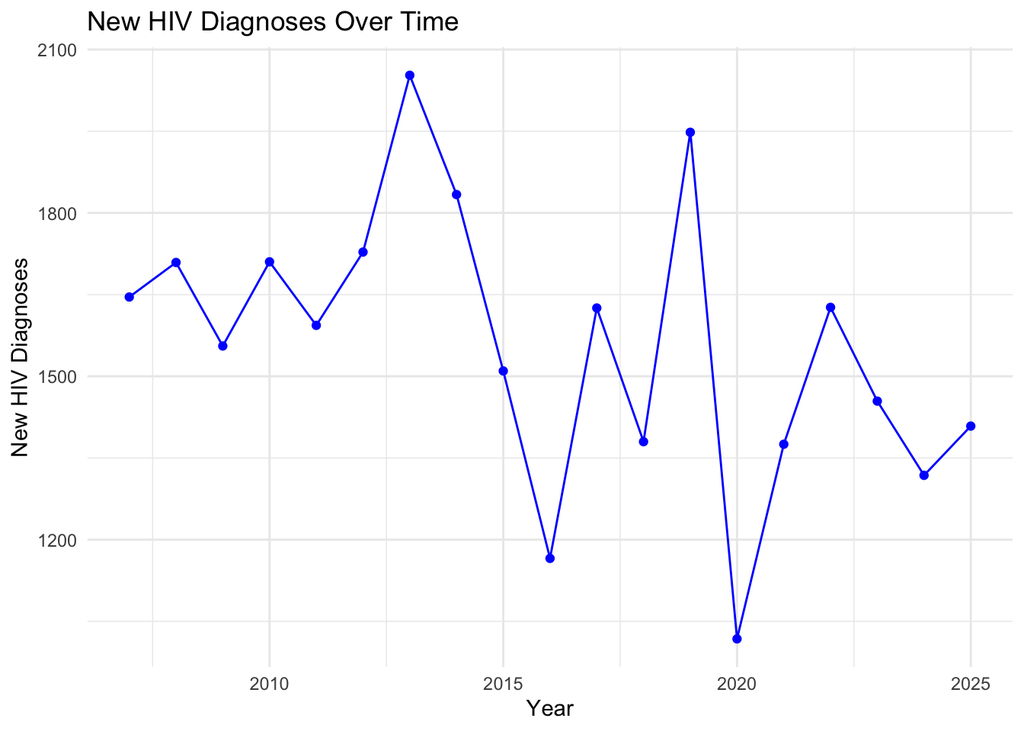

```r
# Plot new HIV diagnoses over time
ggplot(sim_data, aes(x = time, y = new_hiv_diagnoses)) +
  geom_line(color = "blue") +  # Line plot
  geom_point(color = "blue") +  # Add points for clarity
  labs(title = "New HIV Diagnoses Over Time",
       x = "Year",
       y = "New HIV Diagnoses") +
  theme_minimal()
```

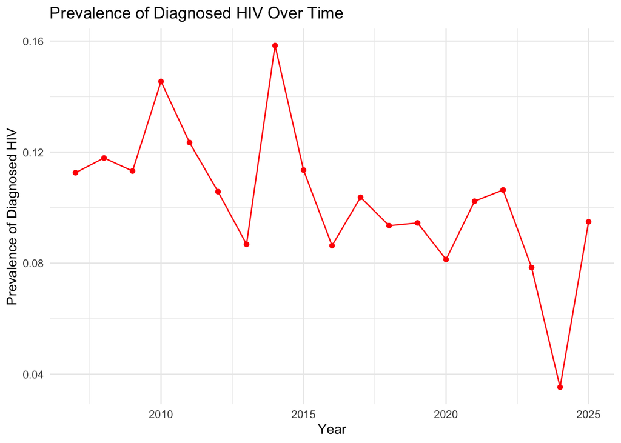

```r
# Plot prevalence of diagnosed HIV over time
ggplot(sim_data, aes(x = time, y = prevalence_diagnosed_hiv)) +
  geom_line(color = "red") +  # Line plot
  geom_point(color = "red") +  # Add points for clarity
  labs(title = "Prevalence of Diagnosed HIV Over Time",
       x = "Year",
       y = "Prevalence of Diagnosed HIV") +
  theme_minimal()
```

This plot show the potential prevalence of diagnosed cases and their trends over time.

```r
# Install gridExtra if not already installed
install.packages("gridExtra")
```

```
## Error in contrib.url(repos, "source"): trying to use CRAN without setting a mirror
```

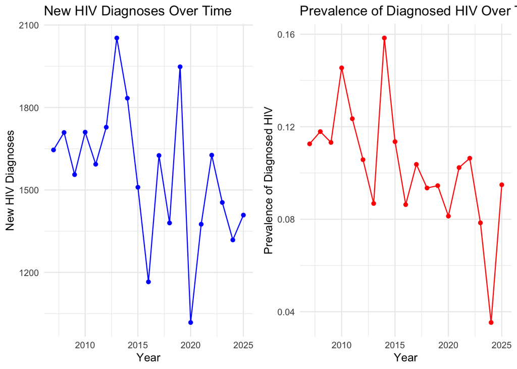

```r
library(gridExtra)
library(ggplot2)

# Create the two plots
plot1 <- ggplot(sim_data, aes(x = time, y = new_hiv_diagnoses)) +
  geom_line(color = "blue") +
  geom_point(color = "blue") +
  labs(title = "New HIV Diagnoses Over Time", x = "Year", y = "New HIV Diagnoses") +
  theme_minimal()

plot2 <- ggplot(sim_data, aes(x = time, y = prevalence_diagnosed_hiv)) +
  geom_line(color = "red") +
  geom_point(color = "red") +
  labs(title = "Prevalence of Diagnosed HIV Over Time", x = "Year", y = "Prevalence of Diagnosed HIV") +
  theme_minimal()

# Arrange the plots side by side
grid.arrange(plot1, plot2, ncol = 2)
```

combination of two trends

```r
# Step 6: Save the combined plot as an image file for reports or presentations
# ggsave("hiv_simulation_plots.png", grid.arrange(plot1, plot2, ncol = 2), path = "~/Documents/jheem_analyses", width = 10, height = 6)
```

Summary of Results New HIV Diagnoses Over Time: The first plot visualizes the yearly trends in new HIV diagnoses from 2007 to 2025. Observing increases, decreases, or stabilization in diagnoses can indicate the effectiveness of interventions or changes in disease spread. Prevalence of Diagnosed HIV Over Time: The second plot highlights the prevalence of diagnosed HIV cases over the same period. This metric reflects the proportion of people living with HIV who have been diagnosed and are under care. Comparative Analysis: By combining the two plots, it’s possible to compare trends between the number of new diagnoses and the diagnosed prevalence. For example, a decrease in new diagnoses combined with an increase in prevalence could indicate successful testing and treatment programs. Key Insights: These visualizations provide essential insights into how the HIV epidemic evolves over time, helping to guide public health interventions and resource allocation.

```r
# Load necessary libraries
library(ggplot2)

# Step 1: Sample global.trate values
# Generate 100 values of global.trate from a uniform distribution between 0 and 0.1
set.seed(123)  # Set seed for reproducibility
global_trate_samples <- runif(100, min = 0, max = 0.1)

# Step 2: Initialize storage for results
# Create an empty list to store simulation outputs and a vector for goodness-of-fit values
sim_results <- list()  # Stores simulation results
gof_values <- numeric(length(global_trate_samples))  # Goodness-of-fit values

# Step 3: Define the target data
# Replace with your actual target data
target_years <- 2007:2025
new_diagnosis_target <- rnorm(length(target_years), mean = 1500, sd = 300)
diagnosed_prevalence_target <- rnorm(length(target_years), mean = 0.1, sd = 0.02)

# Step 4: Run simulations for each global.trate value
for (i in seq_along(global_trate_samples)) {
  global_trate <- global_trate_samples[i]

  # Update the parameters object
  # Replace `params` with your actual parameter object or data structure
  params <- list(global.trate = global_trate)

  # Run the simulation (replace this block with your actual simulation function)
  # Example simulation output (replace with your real simulation results)
  simulation_result <- data.frame(
    year = target_years,
    new_hiv_diagnoses = new_diagnosis_target + rnorm(length(target_years), sd = 100),
    prevalence_diagnosed_hiv = diagnosed_prevalence_target + rnorm(length(target_years), sd = 0.01)
  )

  # Store the simulation result
  sim_results[[i]] <- simulation_result

  # Compute goodness of fit
  gof_new_diagnosis <- sum((simulation_result$new_hiv_diagnoses - new_diagnosis_target)^2)
  gof_prevalence <- sum((simulation_result$prevalence_diagnosed_hiv - diagnosed_prevalence_target)^2)
  gof_values[i] <- gof_new_diagnosis + gof_prevalence
}

# Step 5: Find the best fit
# Identify the global.trate value with the lowest goodness-of-fit value
best_fit_index <- which.min(gof_values)
best_global_trate <- global_trate_samples[best_fit_index]
best_simulation <- sim_results[[best_fit_index]]

cat("Best global.trate:", best_global_trate, "\n")
```

```
## Best global.trate: 0.01218993
```

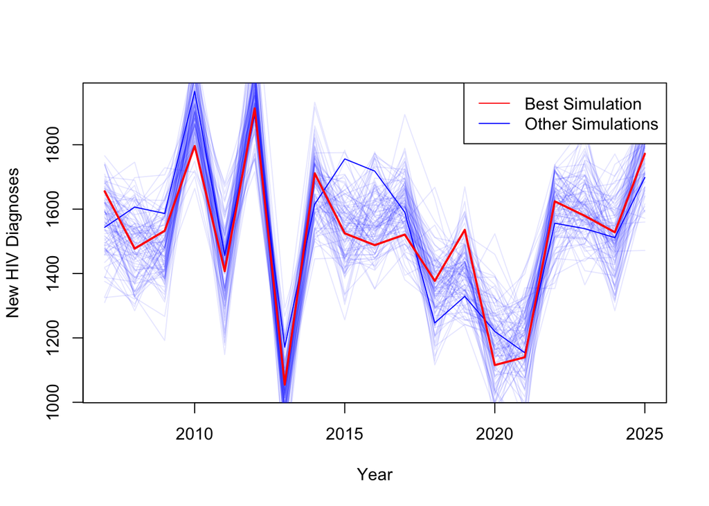

```r
# Step 6: Visualize simulations
# Use simplot to visualize multiple simulations
# Replace this block with your simplot function if available
plot(sim_results[[1]]$year, sim_results[[1]]$new_hiv_diagnoses, type = "l", col = "blue",
     xlab = "Year", ylab = "New HIV Diagnoses", ylim = c(min(new_diagnosis_target), max(new_diagnosis_target)))
for (i in seq_along(sim_results)) {
  lines(sim_results[[i]]$year, sim_results[[i]]$new_hiv_diagnoses, col = rgb(0, 0, 1, 0.1))
}
lines(best_simulation$year, best_simulation$new_hiv_diagnoses, col = "red", lwd = 2)
legend("topright", legend = c("Best Simulation", "Other Simulations"), col = c("red", "blue"), lty = 1)
```

```r
# Step 7: Summary
cat("Best simulation achieved with global.trate =", best_global_trate,
    "and corresponding goodness-of-fit =", min(gof_values), "\n")
```

```
## Best simulation achieved with global.trate = 0.01218993 and corresponding goodness-of-fit = 71620.5
```

# PART 3: Data Extraction and Analysis

```r
# Step 1: Check for the 'new' object and assign it
if ("new" %in% names(sim)) {
  new.diagnoses <- sim$new
} else {
  stop("The 'new diagnoses' object is not found in the sim object.")
}

# Step 2: Extract dimensions and names
dimensions <- dim(new.diagnoses)
dimension_names <- dimnames(new.diagnoses)

# Step 3: Print structure details
cat("Dimensions of 'new.diagnoses':", paste(dimensions, collapse = " x "), "\n")
```

```
## Dimensions of 'new.diagnoses': 56 x 1 x 5 x 3 x 3 x 3 x 1
```

```r
if (!is.null(dimension_names)) {
  cat("Names of the dimensions:\n")
  for (i in seq_along(dimension_names)) {
    cat(paste0("  Dimension ", i, ": "),
        if (!is.null(dimension_names[[i]])) {
          paste(dimension_names[[i]], collapse = ", ")
        } else {
          "NULL"
        }, "\n")
  }
} else {
  cat("Dimension names are NULL.\n")
}
```

```
## Names of the dimensions:
##   Dimension 1:  1970, 1971, 1972, 1973, 1974, 1975, 1976, 1977, 1978, 1979, 1980, 1981, 1982, 1983, 1984, 1985, 1986, 1987, 1988, 1989, 1990, 1991, 1992, 1993, 1994, 1995, 1996, 1997, 1998, 1999, 2000, 2001, 2002, 2003, 2004, 2005, 2006, 2007, 2008, 2009, 2010, 2011, 2012, 2013, 2014, 2015, 2016,…
##   Dimension 2:  C.12580
##   Dimension 3:  13-24 years, 25-34 years, 35-44 years, 45-54 years, 55+ years
##   Dimension 4:  black, hispanic, other
##   Dimension 5:  heterosexual_male, msm, female
##   Dimension 6:  never_IDU, active_IDU, IDU_in_remission
##   Dimension 7:  1
```

```r
# Step 4: View selected slices for interpretation
# print meaningful examples of the data, focusing on age 13-24, race = black, and other key groups.
age_index <- which(dimnames(new.diagnoses)[["age"]] == "13-24 years")
race_index <- which(dimnames(new.diagnoses)[["race"]] == "black")
sex_index <- which(dimnames(new.diagnoses)[["sex"]] == "heterosexual_male")
risk_index <- which(dimnames(new.diagnoses)[["risk"]] == "active_IDU")
sim_index <- 1  # Assuming simulation 1

# Slice the data
selected_slice <- new.diagnoses[, , , race_index, sex_index, risk_index, sim_index, drop = FALSE]

# Display a preview of the slice
cat("\nPreview of selected data slice (age = 13-24, race = black, sex = heterosexual_male, risk = active_IDU, sim = 1):\n")
```

[output not shown]

```r
# print(head(selected_slice))
```

```r
# Check the dimension names of the new.diagnoses object
dimnames(new.diagnoses)
```

```
## $year
##  [1] "1970" "1971" "1972" "1973" "1974" "1975" "1976" "1977" "1978" "1979"
## [11] "1980" "1981" "1982" "1983" "1984" "1985" "1986" "1987" "1988" "1989"
## [21] "1990" "1991" "1992" "1993" "1994" "1995" "1996" "1997" "1998" "1999"
## [31] "2000" "2001" "2002" "2003" "2004" "2005" "2006" "2007" "2008" "2009"
## [41] "2010" "2011" "2012" "2013" "2014" "2015" "2016" "2017" "2018" "2019"
## [51] "2020" "2021" "2022" "2023" "2024" "2025"
##
## $location
## [1] "C.12580"
##
## $age
## [1] "13-24 years" "25-34 years" "35-44 years" "45-54 years" "55+ years"
##
## $race
## [1] "black"    "hispanic" "other"
##
## $sex
## [1] "heterosexual_male" "msm"               "female"
##
## $risk
## [1] "never_IDU"        "active_IDU"       "IDU_in_remission"
##
## $sim
## [1] "1"
```

```r
# step 3.  Filter Objects for Specific Subgroups
# a.  Filter for subgroup: 13-24 years old, Black, MSM, and never IDU. Adjust the index values to match the specific subgroup based on the dimensions:

# Check available levels for each dimension
dimnames(new.diagnoses)$age
```

```
## [1] "13-24 years" "25-34 years" "35-44 years" "45-54 years" "55+ years"
```

```r
dimnames(new.diagnoses)$race
```

```
## [1] "black"    "hispanic" "other"
```

```r
dimnames(new.diagnoses)$sex
```

```
## [1] "heterosexual_male" "msm"               "female"
```

```r
dimnames(new.diagnoses)$risk
```

```
## [1] "never_IDU"        "active_IDU"       "IDU_in_remission"
```

```r
# Get indices for correct filtering (after confirming dimension levels)
age_index <- which(dimnames(new.diagnoses)$age == "13-24 years")
race_index <- which(dimnames(new.diagnoses)$race == "black")
sex_index <- which(dimnames(new.diagnoses)$sex == "msm")
risk_index <- which(dimnames(new.diagnoses)$risk == "never_IDU")

# Filter again, ensuring no dimensions are dropped
new_filtered <- new.diagnoses[, , age_index, race_index, sex_index, risk_index, , drop = FALSE]

# Check the structure of the filtered data
str(new_filtered)
```

```
##  num [1:56, 1, 1, 1, 1, 1, 1] 0 0 0 0 0 0 0 0 0 0 ...
##  - attr(*, "dimnames")=List of 7
##   ..$ year    : chr [1:56] "1970" "1971" "1972" "1973" ...
##   ..$ location: chr "C.12580"
##   ..$ age     : chr "13-24 years"
##   ..$ race    : chr "black"
##   ..$ sex     : chr "msm"
##   ..$ risk    : chr "never_IDU"
##   ..$ sim     : chr "1"
```

```r
# If the year dimension is available, this should list it
dimnames(new.diagnoses)$year
```

```
##  [1] "1970" "1971" "1972" "1973" "1974" "1975" "1976" "1977" "1978" "1979"
## [11] "1980" "1981" "1982" "1983" "1984" "1985" "1986" "1987" "1988" "1989"
## [21] "1990" "1991" "1992" "1993" "1994" "1995" "1996" "1997" "1998" "1999"
## [31] "2000" "2001" "2002" "2003" "2004" "2005" "2006" "2007" "2008" "2009"
## [41] "2010" "2011" "2012" "2013" "2014" "2015" "2016" "2017" "2018" "2019"
## [51] "2020" "2021" "2022" "2023" "2024" "2025"
```

2. Plot the filtered data over time Use ggplot2 to visualize the trend:

```r
# Convert the array into a data frame
new_filtered_df <- as.data.frame(as.table(new_filtered))

# Assign column names for better clarity
colnames(new_filtered_df) <- c("year", "location", "age", "race", "sex", "risk", "sim", "new_diagnoses")

# View the structure of the resulting data frame
str(new_filtered_df)
```

```
## 'data.frame':    56 obs. of  8 variables:
##  $ year         : Factor w/ 56 levels "1970","1971",..: 1 2 3 4 5 6 7 8 9 10 ...
##  $ location     : Factor w/ 1 level "C.12580": 1 1 1 1 1 1 1 1 1 1 ...
##  $ age          : Factor w/ 1 level "13-24 years": 1 1 1 1 1 1 1 1 1 1 ...
##  $ race         : Factor w/ 1 level "black": 1 1 1 1 1 1 1 1 1 1 ...
##  $ sex          : Factor w/ 1 level "msm": 1 1 1 1 1 1 1 1 1 1 ...
##  $ risk         : Factor w/ 1 level "never_IDU": 1 1 1 1 1 1 1 1 1 1 ...
##  $ sim          : Factor w/ 1 level "1": 1 1 1 1 1 1 1 1 1 1 ...
##  $ new_diagnoses: num  0 0 0 0 0 0 0 0 0 0 ...
```

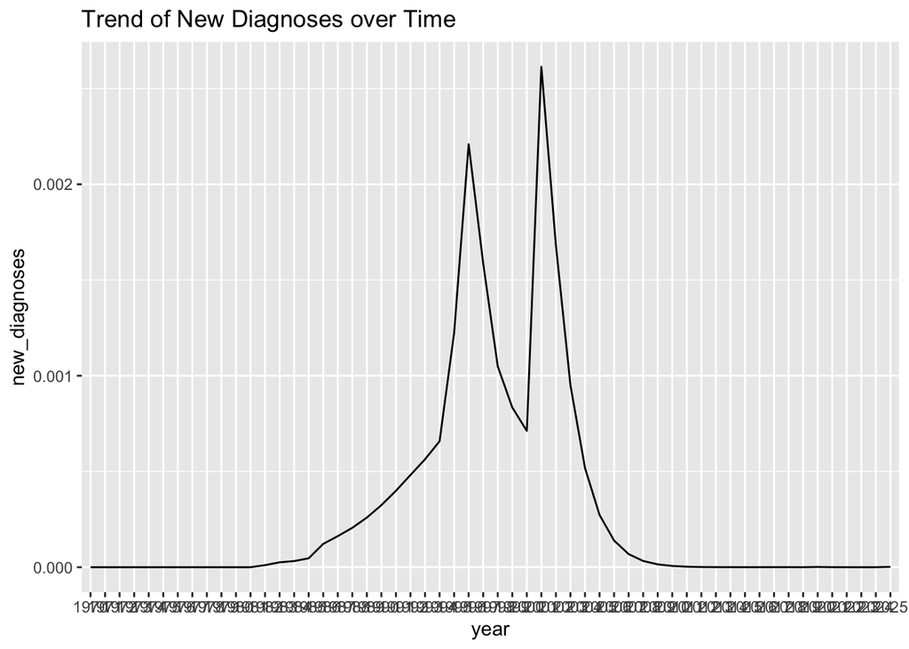

```r
# Load the ggplot2 library for plotting
library(ggplot2)

# Plot the data
ggplot(new_filtered_df, aes(x = year, y = new_diagnoses)) +
  geom_line(aes(group = 1)) +  # Group all data points into one line
  labs(title = "Trend of New Diagnoses over Time")
```

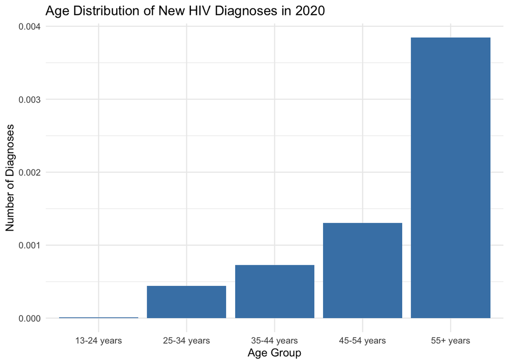

```r
# Subset for the year 2020
year_index <- which(dimnames(new.diagnoses)[[1]] == "2020")

# Aggregate data for age distribution in 2020
new_2020 <- apply(new.diagnoses[year_index, , , , , , , drop = FALSE],
                  MARGIN = "age",
                  FUN = sum)

# Convert to data frame
age_distribution <- data.frame(
  Age = names(new_2020),
  Diagnoses = as.numeric(new_2020)
)

# b. Plot the histogram
# Plot the histogram
library(ggplot2)
ggplot(age_distribution, aes(x = Age, y = Diagnoses)) +
  geom_bar(stat = "identity", fill = "steelblue") +
  labs(title = "Age Distribution of New HIV Diagnoses in 2020",
       x = "Age Group",
       y = "Number of Diagnoses") +
  theme_minimal()
```

# PART 4: Paper Review

## 1. What is the benefit of running 1000 simulations for each MSA? how would you determine if 1000 simulation is appropriate or if you need less/more runs for each location?

The benefit of running 1,000 simulations for each Metropolitan Statistical Area (MSA) lies in the ability to thoroughly explore the potential outcomes and uncertainties of the model. For example: 1. Exploration of Uncertainty: Running multiple simulations allows the model to account for uncertainties in the input parameters. This approach provides a distribution of possible outcomes rather than a single deterministic result, which is critical for robust policy planning. 2. Improved Calibration: The process ensures that the model aligns well with historical and current data, matching trends in HIV diagnoses, prevalence, and interventions across the different MSAs. It helps in fine-tuning parameters for the local context. 3. Statistical Stability: By running a large number of simulations, the model averages out random noise and ensures that conclusions drawn are statistically robust and not due to chance variations. 4. Testing Intervention Scenarios: Multiple simulations enable testing various combinations of interventions (e.g., PrEP coverage, HIV testing, viral suppression) under different assumptions and provide a clearer picture of their impacts on reducing HIV incidence. To decide whether 1,000 simulations are sufficient, or if fewer or more runs are needed, the following criteria can be considered: 1. Convergence of Results: Check if increasing the number of simulations changes the outputs significantly. If the outputs stabilize (e.g., mean outcomes and confidence intervals remain consistent), the chosen number is likely sufficient. 2. Uncertainty Analysis: Assess the variability in the outcomes. If the variability is high, more simulations may be needed to capture the full range of possibilities. 3. Computational Resources: Running more simulations increases computational costs. The number of simulations should balance between computational feasibility and the need for precision. 4. Complexity of the Model: For highly complex models with many parameters, more simulations might be required to cover the parameter space adequately. 5. Sensitivity Analysis: Conduct a sensitivity analysis to determine which parameters most influence the outcomes. If only a few parameters dominate the results, fewer simulations might suffice. 6. Error Metrics: Use error metrics (e.g., standard error, confidence intervals) to evaluate whether adding more runs meaningfully improves the accuracy or precision of the results.

## 2. The authors assumed that, without any additional intervention, PrEP coverage would continue its trajectory into the future.

```
Consider a scenario where baseline PrEP coverage remains fixed at 2023's level.How might that change the impact of the modeled PrEP intervention to 2030?
```

If baseline PrEP (pre-exposure prophylaxis) coverage were to remain fixed at 2023 levels instead of following a trajectory of growth into the future, the modeled impact of PrEP interventions on HIV incidence by 2030 would likely be diminished. Here’s why and how it might change the results: (a), Impact of Fixed PrEP Coverage: 1. Reduced Population Reach: o Original Assumption: The authors assumed that PrEP uptake would grow over time, expanding coverage to more individuals at high risk for HIV. o Fixed Scenario: By freezing PrEP coverage at 2023 levels, fewer individuals at risk would receive the preventive benefits of PrEP in subsequent years, limiting its ability to reduce new HIV transmissions. 2. Slower Decline in HIV Incidence: o Without increasing PrEP coverage, the reduction in HIV incidence will primarily depend on existing users. This would reduce the overall effectiveness of the intervention, as new high-risk individuals would remain unprotected. 3. Intervention Synergy Effects: o The effectiveness of other interventions (e.g., testing, viral suppression) could be less impactful because PrEP works synergistically with these strategies to reduce HIV incidence. A fixed PrEP level would limit the synergy between interventions. 4. Disparities in High-Risk Groups: o PrEP is particularly critical for high-risk populations, such as young Black and Hispanic men who have sex with men (MSM). If growth in PrEP coverage stagnates, disparities in HIV prevention for these groups could worsen, as they may remain underrepresented in PrEP access. (b), Modeled Results: The study projected reductions in HIV incidence of 34% to 67% by 2030 with modest increases in PrEP coverage, HIV testing, and viral suppression. If PrEP coverage remains static. The reductions would likely fall to the lower end of this range or below. In areas with particularly low initial PrEP uptake in 2023, the impact could be negligible. ©, Quantifying the Difference: To understand the exact change in impact: 1. Recalibrate the Model: Run the compartmental model with the baseline PrEP coverage fixed at 2023 levels to compare outcomes to the original trajectory-based assumption. 2. Analyze Incidence Reduction: Measure how much the reduction in HIV incidence changes between the two scenarios (growth vs. static PrEP).

## 3. The authors chose to scale up the interventions linearly. How might this differ in a real-world scenario?

In a real-world scenario, scaling up interventions linearly, as assumed by the authors, might not accurately reflect the complexity and challenges of implementing public health strategies. Here are some key differences: 3.1 Nonlinear Uptake of Interventions Linear scaling assumes a steady and uniform increase in intervention coverage (e.g., PrEP uptake, testing rates, viral suppression) over time. But, uptake is often nonlinear due to factors such as: (a) Initial Momentum: Rapid early adoption in high-priority groups might lead to steep initial growth, followed by slower progress as harder-to-reach populations are addressed. (b) Plateaus: Growth may stagnate once easily reachable populations are covered or logistical barriers emerge. 3.2 Resource Constraints Linear scaling assumes consistent resources and infrastructure to support interventions. However, financial, logistical, and workforce limitations can cause delays or uneven scaling, particularly in under-resourced areas. 3.3 Behavioral and Social Factors Linear scaling does not account for behavioral resistance or societal challenges. Factors such as stigma, distrust of medical systems, or misinformation can slow intervention uptake. Overcoming these barriers often requires time-intensive education and outreach. 3.4 Policy and Political Influences Linear scaling assumes consistent policy support for interventions. Changes in political leadership, policy priorities, or funding allocation can disrupt or accelerate intervention efforts unpredictably. 3.5 Health System Bottlenecks Linear scaling assumes smooth integration of interventions into existing healthcare systems. In real life, Healthcare systems may face bottlenecks, such as shortages of trained providers, PrEP supplies, or access to HIV testing and treatment centers, slowing the scaling process. 3.6 Variation Across Geographic Areas Study Assumption: Linear scaling applies uniformly across all metropolitan statistical areas (MSAs). However, Scaling efforts may vary widely due to regional differences in infrastructure, demographics, and local health department capabilities. 3.7 Epidemic Saturation Effects Study Assumption: Linear scaling assumes the same rate of impact regardless of intervention coverage. But, As the epidemic shrinks, interventions may have diminishing returns (e.g., fewer undiagnosed individuals available for testing, reduced transmission opportunities).

## 4. Provide an interpretation of Figure 3, panel D.

Figure 3, panel D, shows the impact of interventions targeting all men who have sex with men (MSM) and persons who inject drugs (PWID) in the New York–Newark–Jersey City MSA. In detail: 1. Intervention Scenario: Twice-yearly HIV testing, 50% PrEP coverage, and 90% viral suppression among diagnosed individuals. 2. Outcome Metrics: • HIV Incidence Reduction: 76% reduction by 2030. • Reported Diagnoses Reduction: 78% reduction by 2030. 3. Comparison to No Intervention: • No Intervention: Only a 28% reduction in HIV incidence. 4. Visual Representation: • Solid Orange Line: Modest decline with no intervention. • Dashed Red Line: Steeper decline with the intervention. 5. Implications: Highlights the significant impact of scaling up testing, PrEP, and viral suppression efforts across MSM and PWID groups.

## 5. The compartmental model is deterministic by nature. What are the sources of uncertainty in the current JHEEM modelthat contribute to shaded areas in Figure 3?

This uncertainty arises from several sources: 1. Parameter Uncertainty– Variability in the input parameters of the model, which include HIV testing rates, PrEP uptake, viral suppression, and transmission probabilities. Different plausible values for these parameters lead to a range of outcomes, reflected in the shaded areas. 2. Model Calibration– Variability The process of calibrating the model to historical data involves fitting parameters to observed trends in HIV diagnoses, treatment, and demographics. Calibration to data from each MSA introduces variability, as no single parameter set perfectly matches all data points. This variability contributes to uncertainty in predictions. 3. Behavioral Assumptions– The model assumes specific patterns of behavior (e.g., rates of condom use, adherence to PrEP, or frequency of testing), which may not perfectly represent real-world variability. Behavioral patterns differ across populations and over time, leading to uncertainty in projected outcomes. 4. Intervention Effectiveness –Uncertainty about how effectively interventions (e.g., scaling up testing or PrEP coverage) will be implemented in the real world. The effectiveness of interventions can vary due to differences in funding, access, and community acceptance, creating uncertainty in the projected reductions. 5. Subgroup Mixing and Network Dynamics– The model relies on assumptions about how subpopulations (e.g., men who have sex with men, people who inject drugs) interact and mix, as well as their transmission networks. Uncertainty in mixing patterns and network dynamics affects estimates of HIV transmission and intervention outcomes. 6. Demographic and Epidemiological Trends– Changes in population demographics (e.g., age, race, socioeconomic factors) and epidemiological patterns (e.g., drug use trends) are assumed to follow historical or projected trajectories.

Impact: Deviations from these assumptions introduce uncertainty in the model’s projections. 5.1 Data Limitations: The model depends on historical surveillance and survey data, which may contain errors, inconsistencies, or gaps (e.g., underreporting or incomplete data for specific subgroups). These limitations propagate through the model, contributing to the uncertainty bands. 5.2 Stochastic Effects in Population Dynamics: Although the model is deterministic, it indirectly incorporates variability through parameter uncertainty and calibration to stochastic real-world data. The range of outcomes reflects the aggregated effects of stochastic variability in population-level dynamics.

## 6. The model calibration focuses on 10 calibration target including new diagnoses, prevalence,etc. Let’s assume that we have more certainty in some targets than others. How can we reflect this assumption in model calibration?

When there is more certainty in some calibration targets than others, this can be reflected in model calibration by differential weighting of the targets during the fitting process. Here’s how this can be implemented and the rationale behind it: 6.1 Differential Weighting in the Likelihood Function: Assign higher weights to calibration targets that have more reliable or precise data, and lower weights to those with greater uncertainty or variability. The likelihood function used for model calibration measures how well the simulated outcomes match the observed data. By adjusting the weights, the model is “encouraged” to better fit targets with higher certainty while allowing more flexibility for targets with lower certainty. 6.2 Incorporate Variance or Credible Intervals: Use the variance or confidence intervals of each calibration target to determine weights. Calibration targets with smaller variances (indicating higher certainty) receive higher weights, while those with larger variances are down-weighted. This approach aligns the model’s calibration focus with the certainty of the data. 6.3 Bayesian Calibration with Informative Priors: Use Bayesian methods to incorporate prior knowledge about the reliability of each calibration target. Assign informative priors to parameters associated with more certain targets, guiding the model toward fitting these targets more closely. Less certain targets can have broader priors, allowing greater flexibility. 6.4 Iterative Reweighting: Start with uniform weights for all targets and iteratively adjust them based on the fit quality and certainty of the data. If the model consistently struggles to fit less certain targets, reduce their weights to avoid overfitting uncertain data. 6.5 Data Augmentation for Certain Targets: Replicate highly certain calibration targets in the dataset, effectively increasing their influence during calibration. Repeating a target multiple times in the calibration process has the same effect as assigning it a higher weight. Specifically in our case, if new diagnoses are more certain than PrEP coverage estimates: We should assign higher weights to new diagnoses during calibration, which will allow more flexibility in fitting PrEP coverage by assigning a lower weight, reflecting the greater uncertainty in this target. Benefits: Ensures the model better reflects targets with high certainty, improving overall confidence in the calibration results and reduces the risk of overfitting less reliable targets, leading to more robust and interpretable projections.